# Bootstrap Method

### Example: Standard deviation of annual rainfall in Farmville

The data below contains the monthly and annual rainfall totals for Farmville, VA from 1931 until 2011.

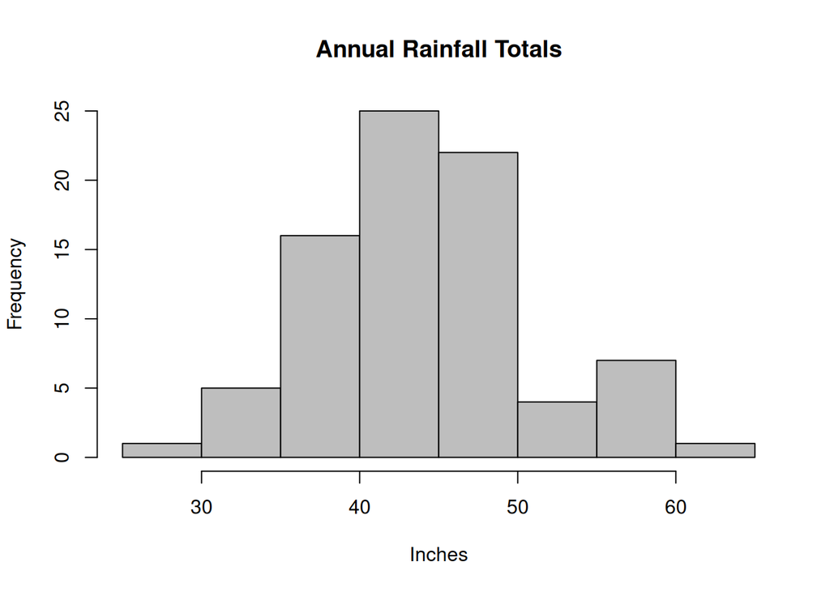

```r
rainfall <- read.csv("http://people.hsc.edu/faculty-staff/blins/StatsExamples/rainfall.csv")
hist(rainfall$total, col = "gray", main = "Annual Rainfall Totals", xlab = "Inches")
```

Suppose we wanted to know how variable rainfall totals are. The right way to compute standard deviation from a sample is to use the sample standard deviation:
$$s = \sqrt{\frac{\sum_{i
= 1}^n (x_i - \bar{x})^2}{N-1}}$$
The standard deviation of the annual rainfall totals is 6.9845 inches per year. That is only a *point estimate*. We might like to make a confidence interval for the parameter $σ_\text{rainfall}$, that is, the true population standard deviation for Farmville annual rainfall amounts. Since we don’t know how to make confidence intervals for standard deviations, we can use a bootstrap distribution.

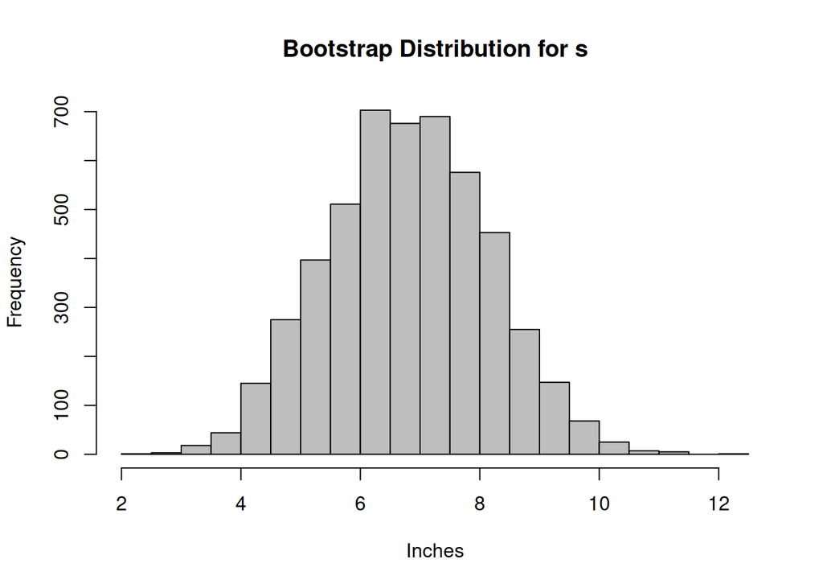

```r
n <- length(rainfall)
B <- 5000
boot.dist <- c()
for (i in 1:B) {
  boot.sample <- sample(rainfall$total, n, replace=T)
  boot.stat <- sd(boot.sample)
  boot.dist <- c(boot.dist, boot.stat)
}
hist(boot.dist, col='gray', main='Bootstrap Distribution for s', xlab='Inches')
```

Once you have the bootstrap distribution, you can make a $(1- \alpha)$-confidence interval for the standard deviation by finding the values of the bootstrap distribution at the percentiles $\alpha/2$ and $(1 - \alpha/2)$. For a 95% confidence interval, we would compute:

```r
quantile(boot.dist, c(0.025, 0.975))
```

```
##     2.5%    97.5%
## 4.261930 9.418046
```

So we can be 95% sure that the true value of $\sigma_\text{rainfall}$ falls between 4.262 and 9.418.